# Analysis, Visualization and Mapping in R

[output not shown]

## Aula 8 Objetivos

- Joins espaciais
- Calculando uma medida de clustering: Moran's I
- Trabalhando com rasters
- Novas visualizações

## Joins espaciais

- Os joins normais usam colunas e valores iguais nas duas tabelas para juntar
- Com dados espaciais, podemos juntar por localização
- Os CRSs precisam ser iguais

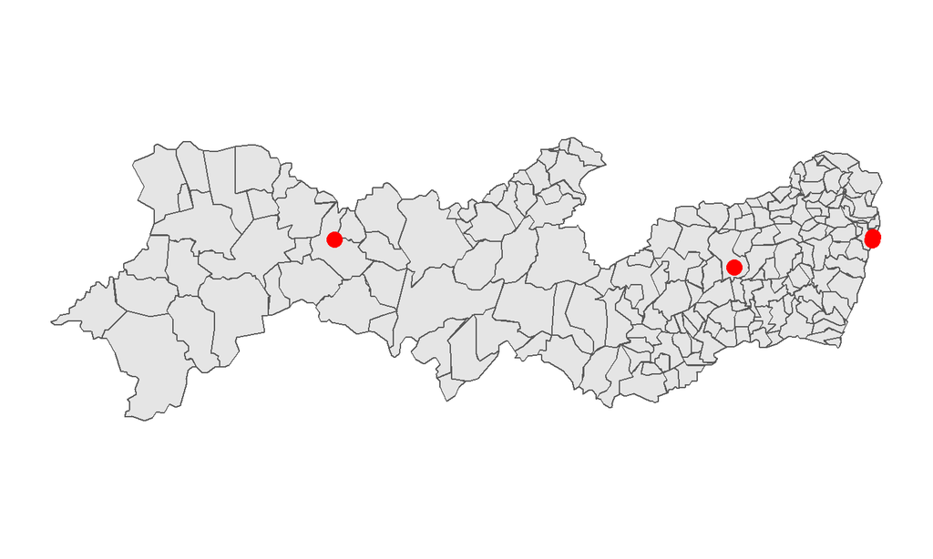

## Joins espaciais

```r
merged <- merged %>% st_transform(4326)
intersects <- sf_points %>% st_join(merged,st_intersects)
```

[output not shown]

## Joins espaciais

- Contagem do número de pontos em cada polígono

```r
intersects %>% group_by(NOME_MUNICIPIO) %>% count()
```

| NOME_MUNICIPIO | n |
| --- | --- |
| CARUARU | 1 |
| RECIFE | 2 |
| SALGUEIRO | 1 |

## Outras operações espaciais

- Distâncias entre pontos

```r
sf_points %>% st_distance()
```

```
## Units: m
##            [,1]       [,2]     [,3]     [,4]
## [1,]      0.000   2641.044 123114.0 467814.3
## [2,]   2641.044      0.000 122332.1 467544.2
## [3,] 123114.037 122332.064      0.0 348199.7
## [4,] 467814.282 467544.169 348199.7      0.0
```

## Outras operações espaciais

- 'Buffer' pontos para polígonos
  - verifique uma projeção em metros

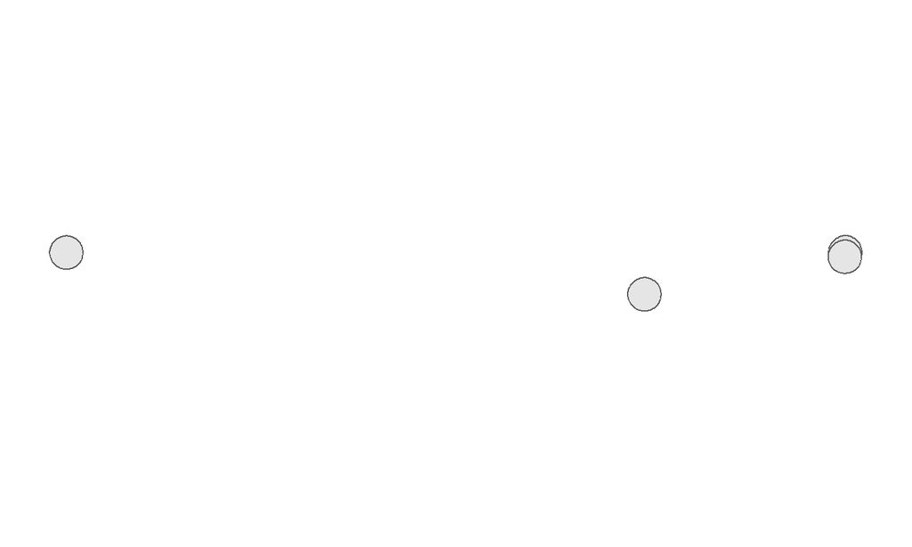

```r
sf_points %>% st_transform(22524) %>%
  st_buffer(10000) %>%
  ggplot() +
  geom_sf() +
  theme_classic() +
  coord_sf(datum=NA)
```

## Outras operações espaciais

- Pontos para polígonos com voronoi polígonos

```r
library(dismo)
sf_voronoi <- merged %>% st_centroid() %>%
  as("Spatial") %>%
  voronoi() %>%
  st_as_sf() %>%
  st_intersection(st_union(shapefile %>% st_transform(4326)))
```

## Outras operações espaciais

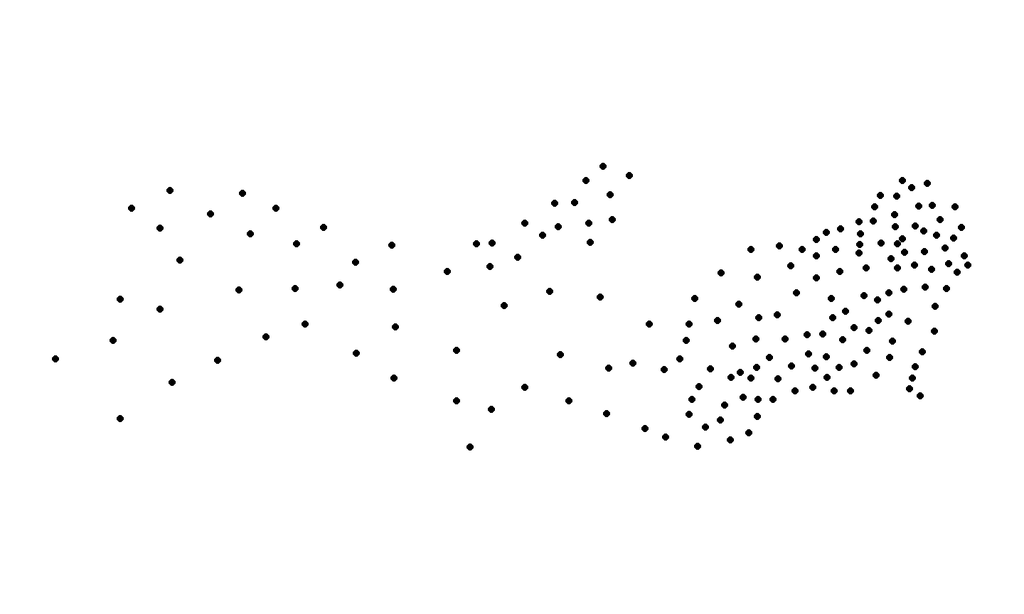

## Outras operações espaciais

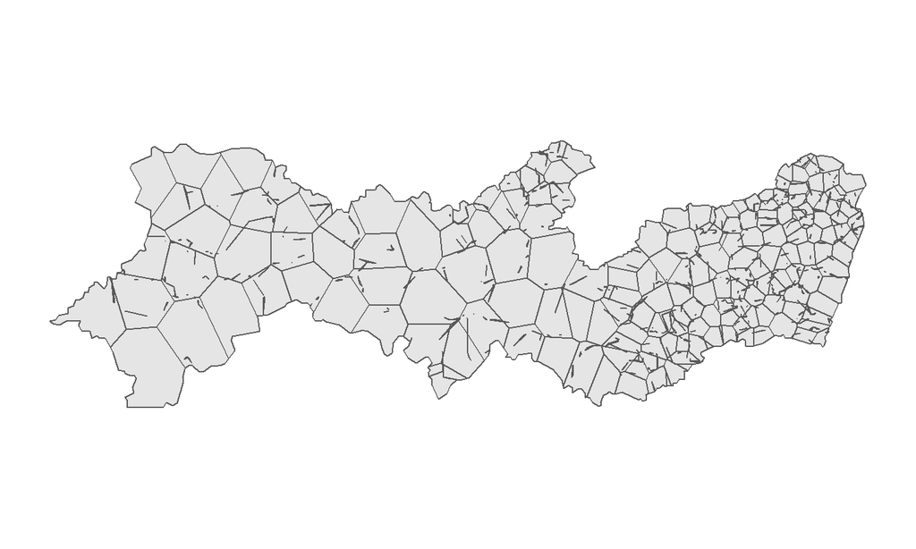

## Calculando clustering: Moran's I

- Uma estatística de clustering

1 - Tirar ilhas (sem vizinhos)

```r
library(spdep)
neighbours1 <- merged %>% as("Spatial") %>% poly2nb(queen=TRUE)
merged_contig <- merged %>% filter(card(neighbours1)!=0)
```

```
## Neighbour list object:
## Number of regions: 183
## Number of nonzero links: 698
## Percentage nonzero weights: 2.084266
## Average number of links: 3.814208
## Link number distribution:
##
##  1  2  3  4  5  6  7  8  9
## 10 36 38 41 29 18  5  4  2
## 10 least connected regions:
## 3 26 39 49 51 110 144 151 171 179 with 1 link
## 2 most connected regions:
## 101 122 with 9 links
```

## Calculando clustering: Moran's I

- Uma estatística de clustering

2 - Identificar vizinhos para cada feature

```r
neighbours2 <- merged_contig %>% as("Spatial") %>% poly2nb(queen=TRUE)
```

```
## Neighbour list object:
## Number of regions: 183
## Number of nonzero links: 698
## Percentage nonzero weights: 2.084266
## Average number of links: 3.814208
## Link number distribution:
##
##  1  2  3  4  5  6  7  8  9
## 10 36 38 41 29 18  5  4  2
## 10 least connected regions:
## 3 26 39 49 51 110 144 151 171 179 with 1 link
## 2 most connected regions:
## 101 122 with 9 links
```

## Calculando clustering: Moran's I

- Uma estatística de clustering

3 - Criar 'ponderação' de vizinhos

```r
neighbours_weights <- neighbours2 %>% nb2listw(style="W")
```

```
## Characteristics of weights list object:
## Neighbour list object:
## Number of regions: 183
## Number of nonzero links: 698
## Percentage nonzero weights: 2.084266
## Average number of links: 3.814208
##
## Weights style: W
## Weights constants summary:
##     n    nn  S0       S1       S2
## W 183 33489 183 110.6125 776.2645
```

## Calculando clustering: Moran's I

- Uma estatística de clustering

4 - Calcular a estatística Moran's I para a variável desejada

```r
merged_contig %>% pull(Vote_Pct) %>%
  moran(neighbours_weights,length(neighbours2),Szero(neighbours_weights)) %>%
  with(I)
```

```
## [1] 0.5724341
```

## Trabalhando com rasters

- Dados de raster estão disponíveis mas enormes (ex. https://ww2.ibge.gov.br/english/geociencias/default_prod.shtm)
- Usar `raster()` para abrir arquivos de tipo .tif
- Podemos acessar imagens de google maps com `gmap`

## Trabalhando com rasters

```r
satellite <- gmap("Recife, Brazil",zoom=16,type="satellite")
```

```
## [1] "try 2 ..."
## [1] "try 3 ..."
```

[figure not shown]

```r
satellite %>% as("SpatialPixelsDataFrame") %>%
  as.data.frame() %>%
  ggplot() +
  geom_tile(aes(x=x,y=y,fill=get(names(satellite)))) +
  coord_equal()
```

## Trabalhando com rasters

[figure not shown]

```r
terrain <- gmap("Recife, Brazil",zoom=16,type="terrain")

terrain %>% as("SpatialPixelsDataFrame") %>%
  as.data.frame() %>%
  ggplot() +
  geom_tile(aes(x=x,y=y,fill=get(names(terrain)))) +
  coord_equal()
```

## Novas visualizações

- O design dos mapas destaca a parte da análise que queremos comunicar
- As vezes, áreas pequenas desaparecem
- Podemos exibir a posição relativa espacial sem exibir a área
  - Cartogram com áreas iguais

```r
devtools::install_github("jbaileyh/geogrid")
library(geogrid)
```

## Novas visualizações

```r
library(geogrid)
sf_hex_grid <- merged %>% calculate_grid(grid_type="hexagonal")
sf_hex_grid <- merged %>% assign_polygons(sf_hex_grid)

hex_map <- sf_hex_grid %>% st_as_sf() %>% ggplot() +
  geom_sf(aes(fill=Vote_Pct)) +
  geom_text(aes(x=V1,y=V2,label=substr(NM_MUNICIP,1,2)),size=2,col="white") +
  theme_classic() +
  coord_sf(datum=NA) +
  xlab("") +
  ylab("")
```

## Novas visualizações

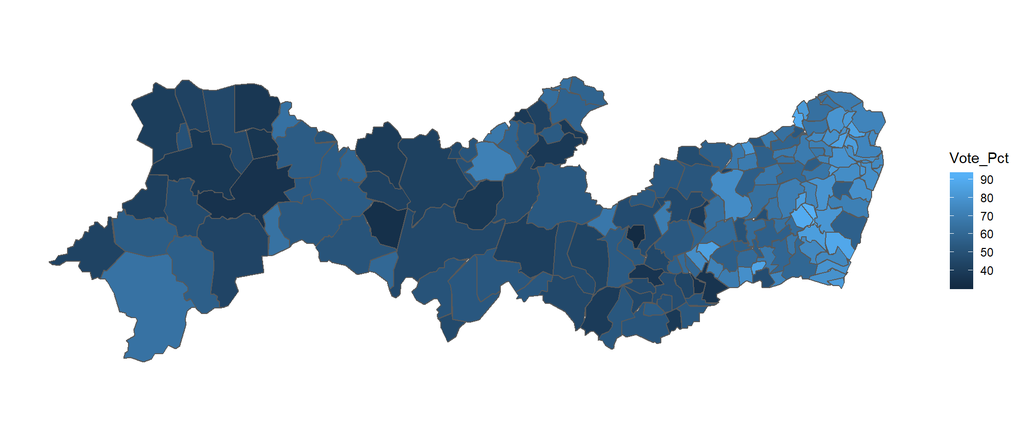

## Novas visualizações

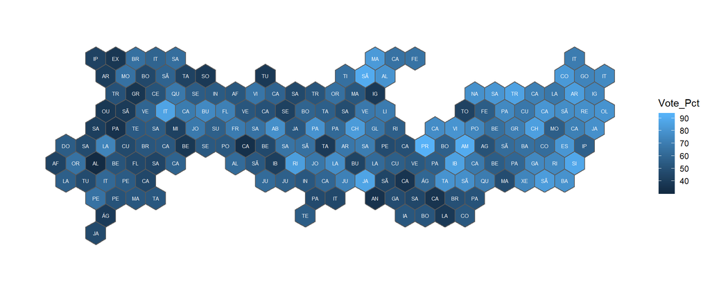